# 3 - Background tab

Simon Garnier

`trackR` uses two different algorithms in order to isolate objects from their surrounding background:

1. **Background subtraction**: this method consists in subtracting an image representing a fixed background from each frame of the video. Pixels with high values in the resulting image will correspond to objects moving in front of the background.
2. **Adaptive thresholding**: this method consists in setting all pixels whose intensities are above a threshold to white and all the remaining pixels to black. In conventional thresholding, the threshold value is the same for all pixels. In adaptive thresholding however, the threshold changes dynamically over the image and is based on the local contrast between each pixel and its immediate surrounding. This allows for the easy detection of dark objects on a light background, and vice versa.

The first method is usually more precise for object detection, but it requires that the background remains fixed for the entire duration of the experiment. The second method does not require that the background remains fixed, as long as the objects to track are always darker (resp. lighter) than their lighter (resp. darker) background. Which method you should choose will depend on the recording conditions of your experiment.

If you choose to use adaptive thresholding, you can skip this section and move directly to the next step. If you choose background subtraction, please follow the instructions below to load a background image (if you have recorded one) or create one from the video.

- 1 - Using an existing background image
- 2 - Creating a background image from the video
- 3 - Removing ghosts

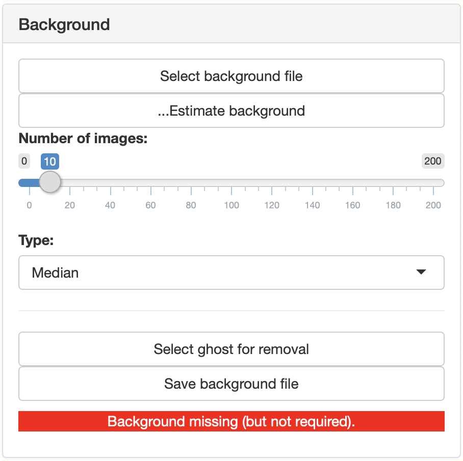

## 1 - Using an existing background image

If you have recorded a background image of your experimental setup, or if you have created and saved one following the instructions in the next section, you can load it by clicking on the `Select background file or...` button in the `Background` tab (see screenshot above). This will bring up a file navigator. Use the file navigator to locate and select the background image that you would like to use. If the image is correctly loaded in `trackR`, it should appear in the display window.

Note: the background image should have the same dimensions as the video.

## 2 - Creating a background image from the video

1. `Mean`: this calculates an average image from the selected video frames. This is a fast algorithm. However it does not always produce good results.
2. `Median`: this calculates a median image from the selected video frames. This usually produces a better result than `Mean`, but will take a significantly longer amount of time.

You can select the algorithm using the `Type` dropdown menu. You can then click on the `...Estimate background` button to start the computation of the background image.

Once the background image is estimated, it should appear in the display window. You can save this image for later use by clicking on the `Save background file` button.

## 3 - Removing ghosts

In some instance (e.g. when an object does not move for a significant portion of the video), the background image may contain “ghosts”. To remove a ghost, click on the `Select ghost for removal` button in the `Background` tab (see screenshot above). Then, use left-mouse clicks in the display window to draw a polygon around the ghost you want to remove (see image below for an example). Close the polygon using a right-mouse click. `trackR` will then use an inpainting algorithm to remove the ghost from the background image.

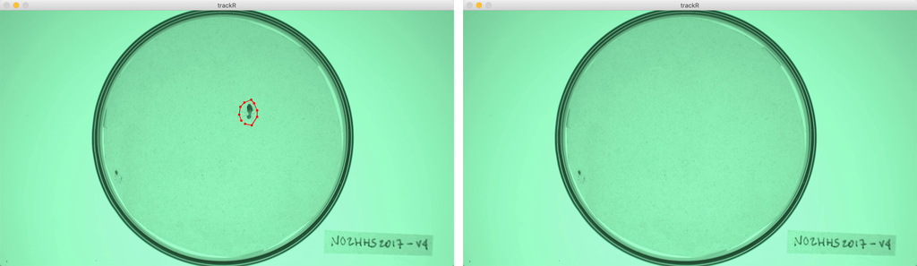

Repeat this operation as many times as necessary to remove all the unwanted ghosts.

Note: inpainting is not an exact science and the result of removing ghosts may not be satisfying. In this case, use a more advanced image editing program such as Adobe Photoshop or Gimp to clean up your background image.